# Risk Factor Analysis

## Outcome Variable

**Outcome Variable:** whz

## Predictor Variables

**Intervention Variable:** predfeed3

**Adjustment Set:**

- arm
- sex
- month
- brthmon
- W_mage
- meducyrs
- feducyrs
- hhwealth_quart
- hfoodsec
- W_mhtcm
- W_mwtkg
- W_mbmi
- vagbrth
- W_gagebrth
- W_birthwt
- W_birthlen
- W_nrooms
- W_nchldlt5
- W_parity
- impfloor
- impsan
- safeh20
- delta_W_mage
- delta_meducyrs
- delta_feducyrs
- delta_hhwealth_quart
- delta_hfoodsec
- delta_W_mhtcm
- delta_W_mwtkg
- delta_W_mbmi
- delta_vagbrth
- delta_W_gagebrth
- delta_W_birthwt
- delta_W_birthlen
- delta_W_nrooms
- delta_W_nchldlt5
- delta_W_parity
- delta_impfloor
- delta_impsan
- delta_safeh20

## Stratifying Variables

The analysis was stratified on these variable(s):

- agecat
- studyid
- country

## Data Summary

| agecat | studyid | country | predfeed3 | n_cell | n | outcome_variable |
| --- | --- | --- | --- | --- | --- | --- |
| Birth | ki0047075b-MAL-ED | BANGLADESH | 1 | 164 | 202 | whz |
| Birth | ki0047075b-MAL-ED | BANGLADESH | 0 | 38 | 202 | whz |
| Birth | ki0047075b-MAL-ED | BRAZIL | 1 | 23 | 55 | whz |
| Birth | ki0047075b-MAL-ED | BRAZIL | 0 | 32 | 55 | whz |
| Birth | ki0047075b-MAL-ED | INDIA | 1 | 27 | 39 | whz |
| Birth | ki0047075b-MAL-ED | INDIA | 0 | 12 | 39 | whz |
| Birth | ki0047075b-MAL-ED | NEPAL | 1 | 14 | 25 | whz |
| Birth | ki0047075b-MAL-ED | NEPAL | 0 | 11 | 25 | whz |
| Birth | ki0047075b-MAL-ED | PERU | 1 | 145 | 218 | whz |
| Birth | ki0047075b-MAL-ED | PERU | 0 | 73 | 218 | whz |
| Birth | ki0047075b-MAL-ED | SOUTH AFRICA | 1 | 33 | 99 | whz |
| Birth | ki0047075b-MAL-ED | SOUTH AFRICA | 0 | 66 | 99 | whz |
| Birth | ki0047075b-MAL-ED | TANZANIA, UNITED REPUBLIC OF | 1 | 24 | 95 | whz |
| Birth | ki0047075b-MAL-ED | TANZANIA, UNITED REPUBLIC OF | 0 | 71 | 95 | whz |
| Birth | ki1000109-EE | PAKISTAN | 1 | 22 | 22 | whz |
| Birth | ki1000109-EE | PAKISTAN | 0 | 0 | 22 | whz |
| Birth | ki1113344-GMS-Nepal | NEPAL | 1 | 352 | 422 | whz |
| Birth | ki1113344-GMS-Nepal | NEPAL | 0 | 70 | 422 | whz |
| Birth | kiGH5241-JiVitA-3 | BANGLADESH | 1 | 9638 | 10634 | whz |
| Birth | kiGH5241-JiVitA-3 | BANGLADESH | 0 | 996 | 10634 | whz |
| Birth | kiGH5241-JiVitA-4 | BANGLADESH | 1 | 89 | 97 | whz |
| Birth | kiGH5241-JiVitA-4 | BANGLADESH | 0 | 8 | 97 | whz |
| 6 months | ki0047075b-MAL-ED | BANGLADESH | 1 | 191 | 233 | whz |
| 6 months | ki0047075b-MAL-ED | BANGLADESH | 0 | 42 | 233 | whz |
| 6 months | ki0047075b-MAL-ED | BRAZIL | 1 | 93 | 187 | whz |
| 6 months | ki0047075b-MAL-ED | BRAZIL | 0 | 94 | 187 | whz |
| 6 months | ki0047075b-MAL-ED | INDIA | 1 | 147 | 210 | whz |
| 6 months | ki0047075b-MAL-ED | INDIA | 0 | 63 | 210 | whz |
| 6 months | ki0047075b-MAL-ED | NEPAL | 1 | 113 | 227 | whz |
| 6 months | ki0047075b-MAL-ED | NEPAL | 0 | 114 | 227 | whz |
| 6 months | ki0047075b-MAL-ED | PERU | 1 | 176 | 270 | whz |
| 6 months | ki0047075b-MAL-ED | PERU | 0 | 94 | 270 | whz |
| 6 months | ki0047075b-MAL-ED | SOUTH AFRICA | 1 | 63 | 244 | whz |
| 6 months | ki0047075b-MAL-ED | SOUTH AFRICA | 0 | 181 | 244 | whz |
| 6 months | ki0047075b-MAL-ED | TANZANIA, UNITED REPUBLIC OF | 1 | 64 | 212 | whz |
| 6 months | ki0047075b-MAL-ED | TANZANIA, UNITED REPUBLIC OF | 0 | 148 | 212 | whz |
| 6 months | ki1000109-EE | PAKISTAN | 1 | 39 | 39 | whz |
| 6 months | ki1000109-EE | PAKISTAN | 0 | 0 | 39 | whz |
| 6 months | ki1113344-GMS-Nepal | NEPAL | 1 | 367 | 441 | whz |
| 6 months | ki1113344-GMS-Nepal | NEPAL | 0 | 74 | 441 | whz |
| 6 months | kiGH5241-JiVitA-3 | BANGLADESH | 1 | 8500 | 9310 | whz |
| 6 months | kiGH5241-JiVitA-3 | BANGLADESH | 0 | 810 | 9310 | whz |
| 6 months | kiGH5241-JiVitA-4 | BANGLADESH | 1 | 76 | 88 | whz |
| 6 months | kiGH5241-JiVitA-4 | BANGLADESH | 0 | 12 | 88 | whz |
| 24 months | ki0047075b-MAL-ED | BANGLADESH | 1 | 168 | 205 | whz |
| 24 months | ki0047075b-MAL-ED | BANGLADESH | 0 | 37 | 205 | whz |
| 24 months | ki0047075b-MAL-ED | BRAZIL | 1 | 79 | 152 | whz |
| 24 months | ki0047075b-MAL-ED | BRAZIL | 0 | 73 | 152 | whz |
| 24 months | ki0047075b-MAL-ED | INDIA | 1 | 139 | 202 | whz |
| 24 months | ki0047075b-MAL-ED | INDIA | 0 | 63 | 202 | whz |
| 24 months | ki0047075b-MAL-ED | NEPAL | 1 | 110 | 220 | whz |
| 24 months | ki0047075b-MAL-ED | NEPAL | 0 | 110 | 220 | whz |
| 24 months | ki0047075b-MAL-ED | PERU | 1 | 131 | 198 | whz |
| 24 months | ki0047075b-MAL-ED | PERU | 0 | 67 | 198 | whz |
| 24 months | ki0047075b-MAL-ED | SOUTH AFRICA | 1 | 60 | 228 | whz |
| 24 months | ki0047075b-MAL-ED | SOUTH AFRICA | 0 | 168 | 228 | whz |
| 24 months | ki0047075b-MAL-ED | TANZANIA, UNITED REPUBLIC OF | 1 | 54 | 184 | whz |
| 24 months | ki0047075b-MAL-ED | TANZANIA, UNITED REPUBLIC OF | 0 | 130 | 184 | whz |
| 24 months | ki1000109-EE | PAKISTAN | 1 | 20 | 20 | whz |
| 24 months | ki1000109-EE | PAKISTAN | 0 | 0 | 20 | whz |
| 24 months | ki1113344-GMS-Nepal | NEPAL | 1 | 322 | 384 | whz |
| 24 months | ki1113344-GMS-Nepal | NEPAL | 0 | 62 | 384 | whz |
| 24 months | kiGH5241-JiVitA-3 | BANGLADESH | 1 | 4417 | 4833 | whz |
| 24 months | kiGH5241-JiVitA-3 | BANGLADESH | 0 | 416 | 4833 | whz |
| 24 months | kiGH5241-JiVitA-4 | BANGLADESH | 1 | 135 | 150 | whz |
| 24 months | kiGH5241-JiVitA-4 | BANGLADESH | 0 | 15 | 150 | whz |

The following strata were considered:

- agecat: 24 months, studyid: ki0047075b-MAL-ED, country: BANGLADESH
- agecat: 24 months, studyid: ki0047075b-MAL-ED, country: BRAZIL
- agecat: 24 months, studyid: ki0047075b-MAL-ED, country: INDIA
- agecat: 24 months, studyid: ki0047075b-MAL-ED, country: NEPAL
- agecat: 24 months, studyid: ki0047075b-MAL-ED, country: PERU
- agecat: 24 months, studyid: ki0047075b-MAL-ED, country: SOUTH AFRICA
- agecat: 24 months, studyid: ki0047075b-MAL-ED, country: TANZANIA, UNITED REPUBLIC OF
- agecat: 24 months, studyid: ki1000109-EE, country: PAKISTAN
- agecat: 24 months, studyid: ki1113344-GMS-Nepal, country: NEPAL
- agecat: 24 months, studyid: kiGH5241-JiVitA-3, country: BANGLADESH
- agecat: 24 months, studyid: kiGH5241-JiVitA-4, country: BANGLADESH
- agecat: 6 months, studyid: ki0047075b-MAL-ED, country: BANGLADESH
- agecat: 6 months, studyid: ki0047075b-MAL-ED, country: BRAZIL
- agecat: 6 months, studyid: ki0047075b-MAL-ED, country: INDIA
- agecat: 6 months, studyid: ki0047075b-MAL-ED, country: NEPAL
- agecat: 6 months, studyid: ki0047075b-MAL-ED, country: PERU
- agecat: 6 months, studyid: ki0047075b-MAL-ED, country: SOUTH AFRICA
- agecat: 6 months, studyid: ki0047075b-MAL-ED, country: TANZANIA, UNITED REPUBLIC OF
- agecat: 6 months, studyid: ki1000109-EE, country: PAKISTAN
- agecat: 6 months, studyid: ki1113344-GMS-Nepal, country: NEPAL
- agecat: 6 months, studyid: kiGH5241-JiVitA-3, country: BANGLADESH
- agecat: 6 months, studyid: kiGH5241-JiVitA-4, country: BANGLADESH
- agecat: Birth, studyid: ki0047075b-MAL-ED, country: BANGLADESH
- agecat: Birth, studyid: ki0047075b-MAL-ED, country: BRAZIL
- agecat: Birth, studyid: ki0047075b-MAL-ED, country: INDIA
- agecat: Birth, studyid: ki0047075b-MAL-ED, country: NEPAL
- agecat: Birth, studyid: ki0047075b-MAL-ED, country: PERU
- agecat: Birth, studyid: ki0047075b-MAL-ED, country: SOUTH AFRICA
- agecat: Birth, studyid: ki0047075b-MAL-ED, country: TANZANIA, UNITED REPUBLIC OF
- agecat: Birth, studyid: ki1000109-EE, country: PAKISTAN
- agecat: Birth, studyid: ki1113344-GMS-Nepal, country: NEPAL
- agecat: Birth, studyid: kiGH5241-JiVitA-3, country: BANGLADESH
- agecat: Birth, studyid: kiGH5241-JiVitA-4, country: BANGLADESH

### Dropped Strata

Some strata were dropped due to rare outcomes:

- agecat: Birth, studyid: ki1000109-EE, country: PAKISTAN
- agecat: 6 months, studyid: ki1000109-EE, country: PAKISTAN
- agecat: 24 months, studyid: ki1000109-EE, country: PAKISTAN

## Methods Detail

We’re interested in the causal parameters $E[Y_a]$ for all values of $a \in \mathcal{A}$. These parameters represent the mean outcome if, possibly contrary to fact, we intervened to set all units to have $A=a$. Under the randomization and positivity assumptions, these are identified by the statistical parameters $\psi_a=E_W[E_{Y|A,W}(Y|A=a,W)]$. In addition, we’re interested in the mean of $Y$, $E[Y]$ under no intervention (the observed mean). We will estimate these parameters by using SuperLearner to fit the relevant likelihood factors – $E_{Y|A,W}(Y|A=a,W)$ and $p(A=a|W)$, and then updating our likelihood fit using a joint TMLE.

For unadjusted analyses ($W=\{\}$), initial likelihoods were estimated using Lrnr_glm to estimate the simple $E(Y|A)$ and Lrnr_mean to estimate $p(A)$. For adjusted analyses, a small library containing Lrnr_glmnet, Lrnr_xgboost, and Lrnr_mean was used.

# Results Detail

## Results Plots

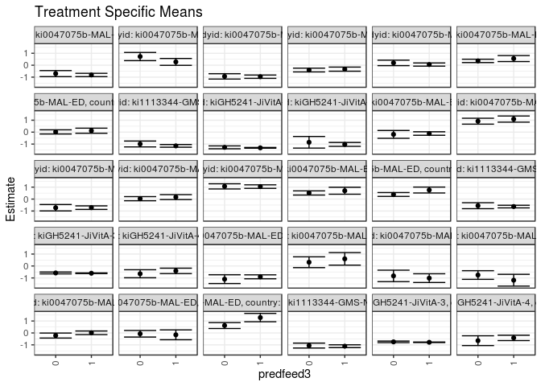

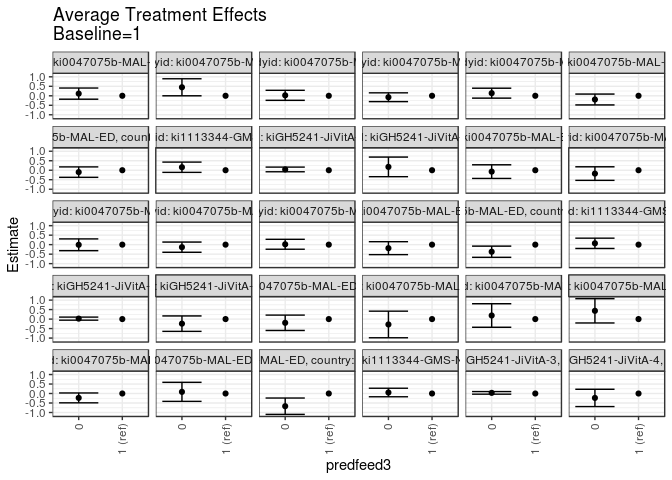

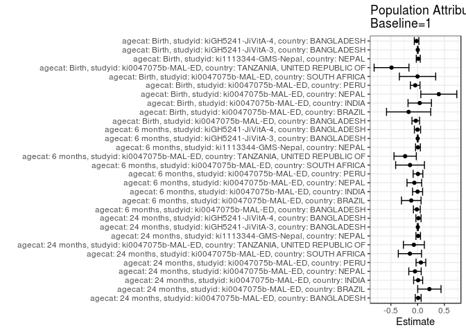

## Results Table

### Parameter: TSM

| agecat | studyid | country | intervention_level | baseline_level | estimate | ci_lower | ci_upper |
| --- | --- | --- | --- | --- | --- | --- | --- |
| Birth | ki0047075b-MAL-ED | BANGLADESH | 1 | NA | -0.9066606 | -1.0725608 | -0.7407603 |
| Birth | ki0047075b-MAL-ED | BANGLADESH | 0 | NA | -1.1022487 | -1.4703929 | -0.7341046 |
| Birth | ki0047075b-MAL-ED | BRAZIL | 1 | NA | 0.5995500 | 0.0737672 | 1.1253329 |
| Birth | ki0047075b-MAL-ED | BRAZIL | 0 | NA | 0.3162128 | -0.1367730 | 0.7691986 |
| Birth | ki0047075b-MAL-ED | INDIA | 1 | NA | -1.0176521 | -1.3837117 | -0.6515925 |
| Birth | ki0047075b-MAL-ED | INDIA | 0 | NA | -0.8288196 | -1.3091678 | -0.3484713 |
| Birth | ki0047075b-MAL-ED | NEPAL | 1 | NA | -1.1906677 | -1.6837159 | -0.6976196 |
| Birth | ki0047075b-MAL-ED | NEPAL | 0 | NA | -0.7555342 | -1.1176410 | -0.3934275 |
| Birth | ki0047075b-MAL-ED | PERU | 1 | NA | 0.0114821 | -0.1392479 | 0.1622121 |
| Birth | ki0047075b-MAL-ED | PERU | 0 | NA | -0.2184957 | -0.4270956 | -0.0098958 |
| Birth | ki0047075b-MAL-ED | SOUTH AFRICA | 1 | NA | -0.1576883 | -0.5689021 | 0.2535256 |
| Birth | ki0047075b-MAL-ED | SOUTH AFRICA | 0 | NA | -0.0704168 | -0.3445936 | 0.2037600 |
| Birth | ki0047075b-MAL-ED | TANZANIA, UNITED REPUBLIC OF | 1 | NA | 1.2873806 | 0.9361719 | 1.6385893 |
| Birth | ki0047075b-MAL-ED | TANZANIA, UNITED REPUBLIC OF | 0 | NA | 0.6188521 | 0.3723567 | 0.8653474 |
| Birth | ki1113344-GMS-Nepal | NEPAL | 1 | NA | -1.1116863 | -1.2299752 | -0.9933974 |
| Birth | ki1113344-GMS-Nepal | NEPAL | 0 | NA | -1.0589807 | -1.2652249 | -0.8527365 |
| Birth | kiGH5241-JiVitA-3 | BANGLADESH | 1 | NA | -0.7830613 | -0.8062987 | -0.7598239 |
| Birth | kiGH5241-JiVitA-3 | BANGLADESH | 0 | NA | -0.7487395 | -0.8152356 | -0.6822434 |
| Birth | kiGH5241-JiVitA-4 | BANGLADESH | 1 | NA | -0.4156180 | -0.6383645 | -0.1928714 |
| Birth | kiGH5241-JiVitA-4 | BANGLADESH | 0 | NA | -0.6475000 | -1.0569566 | -0.2380434 |
| 6 months | ki0047075b-MAL-ED | BANGLADESH | 1 | NA | -0.1160824 | -0.2619166 | 0.0297517 |
| 6 months | ki0047075b-MAL-ED | BANGLADESH | 0 | NA | -0.1889702 | -0.5163286 | 0.1383881 |
| 6 months | ki0047075b-MAL-ED | BRAZIL | 1 | NA | 1.0942169 | 0.8364393 | 1.3519945 |
| 6 months | ki0047075b-MAL-ED | BRAZIL | 0 | NA | 0.9170616 | 0.6703155 | 1.1638076 |
| 6 months | ki0047075b-MAL-ED | INDIA | 1 | NA | -0.7181281 | -0.8667155 | -0.5695407 |
| 6 months | ki0047075b-MAL-ED | INDIA | 0 | NA | -0.7256340 | -0.9943623 | -0.4569057 |
| 6 months | ki0047075b-MAL-ED | NEPAL | 1 | NA | 0.1655702 | -0.0402499 | 0.3713904 |
| 6 months | ki0047075b-MAL-ED | NEPAL | 0 | NA | 0.0331616 | -0.1390253 | 0.2053486 |
| 6 months | ki0047075b-MAL-ED | PERU | 1 | NA | 1.0444164 | 0.8961934 | 1.1926395 |
| 6 months | ki0047075b-MAL-ED | PERU | 0 | NA | 1.0639564 | 0.8473970 | 1.2805159 |
| 6 months | ki0047075b-MAL-ED | SOUTH AFRICA | 1 | NA | 0.6978887 | 0.4065107 | 0.9892668 |
| 6 months | ki0047075b-MAL-ED | SOUTH AFRICA | 0 | NA | 0.5122106 | 0.3379555 | 0.6864657 |
| 6 months | ki0047075b-MAL-ED | TANZANIA, UNITED REPUBLIC OF | 1 | NA | 0.7587148 | 0.5109997 | 1.0064298 |
| 6 months | ki0047075b-MAL-ED | TANZANIA, UNITED REPUBLIC OF | 0 | NA | 0.3856272 | 0.2236248 | 0.5476296 |
| 6 months | ki1113344-GMS-Nepal | NEPAL | 1 | NA | -0.6267145 | -0.7366358 | -0.5167932 |
| 6 months | ki1113344-GMS-Nepal | NEPAL | 0 | NA | -0.5566082 | -0.8061556 | -0.3070608 |
| 6 months | kiGH5241-JiVitA-3 | BANGLADESH | 1 | NA | -0.6062826 | -0.6318518 | -0.5807134 |
| 6 months | kiGH5241-JiVitA-3 | BANGLADESH | 0 | NA | -0.5820910 | -0.6597372 | -0.5044448 |
| 6 months | kiGH5241-JiVitA-4 | BANGLADESH | 1 | NA | -0.4088001 | -0.6365020 | -0.1810981 |
| 6 months | kiGH5241-JiVitA-4 | BANGLADESH | 0 | NA | -0.6495827 | -0.9853569 | -0.3138085 |
| 24 months | ki0047075b-MAL-ED | BANGLADESH | 1 | NA | -0.8191325 | -0.9586072 | -0.6796578 |
| 24 months | ki0047075b-MAL-ED | BANGLADESH | 0 | NA | -0.7042596 | -0.9588519 | -0.4496672 |
| 24 months | ki0047075b-MAL-ED | BRAZIL | 1 | NA | 0.2777825 | -0.0097505 | 0.5653155 |
| 24 months | ki0047075b-MAL-ED | BRAZIL | 0 | NA | 0.7257178 | 0.3826434 | 1.0687922 |
| 24 months | ki0047075b-MAL-ED | INDIA | 1 | NA | -0.9617590 | -1.1016680 | -0.8218499 |
| 24 months | ki0047075b-MAL-ED | INDIA | 0 | NA | -0.9369560 | -1.1608992 | -0.7130128 |
| 24 months | ki0047075b-MAL-ED | NEPAL | 1 | NA | -0.3303450 | -0.5024922 | -0.1581979 |
| 24 months | ki0047075b-MAL-ED | NEPAL | 0 | NA | -0.4048172 | -0.5616035 | -0.2480308 |
| 24 months | ki0047075b-MAL-ED | PERU | 1 | NA | 0.0559197 | -0.0759320 | 0.1877714 |
| 24 months | ki0047075b-MAL-ED | PERU | 0 | NA | 0.1937191 | -0.0350826 | 0.4225208 |
| 24 months | ki0047075b-MAL-ED | SOUTH AFRICA | 1 | NA | 0.5561481 | 0.3060348 | 0.8062614 |
| 24 months | ki0047075b-MAL-ED | SOUTH AFRICA | 0 | NA | 0.3610710 | 0.2207248 | 0.5014171 |
| 24 months | ki0047075b-MAL-ED | TANZANIA, UNITED REPUBLIC OF | 1 | NA | 0.1192874 | -0.0939450 | 0.3325197 |
| 24 months | ki0047075b-MAL-ED | TANZANIA, UNITED REPUBLIC OF | 0 | NA | 0.0196874 | -0.1539163 | 0.1932911 |
| 24 months | ki1113344-GMS-Nepal | NEPAL | 1 | NA | -1.1509975 | -1.2636930 | -1.0383019 |
| 24 months | ki1113344-GMS-Nepal | NEPAL | 0 | NA | -0.9934382 | -1.2394867 | -0.7473897 |
| 24 months | kiGH5241-JiVitA-3 | BANGLADESH | 1 | NA | -1.3145943 | -1.3464426 | -1.2827460 |
| 24 months | kiGH5241-JiVitA-3 | BANGLADESH | 0 | NA | -1.2731854 | -1.3932469 | -1.1531239 |
| 24 months | kiGH5241-JiVitA-4 | BANGLADESH | 1 | NA | -1.0259389 | -1.1888658 | -0.8630119 |
| 24 months | kiGH5241-JiVitA-4 | BANGLADESH | 0 | NA | -0.8499787 | -1.3371815 | -0.3627759 |

### Parameter: E(Y)

| agecat | studyid | country | intervention_level | baseline_level | estimate | ci_lower | ci_upper |
| --- | --- | --- | --- | --- | --- | --- | --- |
| Birth | ki0047075b-MAL-ED | BANGLADESH | NA | NA | -0.9411386 | -1.0895370 | -0.7927402 |
| Birth | ki0047075b-MAL-ED | BRAZIL | NA | NA | 0.4316364 | 0.0969688 | 0.7663039 |
| Birth | ki0047075b-MAL-ED | INDIA | NA | NA | -0.9779487 | -1.2664810 | -0.6894164 |
| Birth | ki0047075b-MAL-ED | NEPAL | NA | NA | -0.7944000 | -1.1625222 | -0.4262778 |
| Birth | ki0047075b-MAL-ED | PERU | NA | NA | -0.0335321 | -0.1564905 | 0.0894263 |
| Birth | ki0047075b-MAL-ED | SOUTH AFRICA | NA | NA | -0.1588889 | -0.3845288 | 0.0667510 |
| Birth | ki0047075b-MAL-ED | TANZANIA, UNITED REPUBLIC OF | NA | NA | 0.7996842 | 0.5874808 | 1.0118876 |
| Birth | ki1113344-GMS-Nepal | NEPAL | NA | NA | -1.0991706 | -1.2073693 | -0.9909719 |
| Birth | kiGH5241-JiVitA-3 | BANGLADESH | NA | NA | -0.7798636 | -0.8022140 | -0.7575133 |
| Birth | kiGH5241-JiVitA-4 | BANGLADESH | NA | NA | -0.4347423 | -0.6441144 | -0.2253701 |
| 6 months | ki0047075b-MAL-ED | BANGLADESH | NA | NA | -0.1304936 | -0.2625419 | 0.0015547 |
| 6 months | ki0047075b-MAL-ED | BRAZIL | NA | NA | 0.9754144 | 0.7990651 | 1.1517638 |
| 6 months | ki0047075b-MAL-ED | INDIA | NA | NA | -0.7185992 | -0.8491469 | -0.5880515 |
| 6 months | ki0047075b-MAL-ED | NEPAL | NA | NA | 0.1041483 | -0.0311352 | 0.2394318 |
| 6 months | ki0047075b-MAL-ED | PERU | NA | NA | 1.0514136 | 0.9289176 | 1.1739096 |
| 6 months | ki0047075b-MAL-ED | SOUTH AFRICA | NA | NA | 0.5564071 | 0.4055220 | 0.7072922 |
| 6 months | ki0047075b-MAL-ED | TANZANIA, UNITED REPUBLIC OF | NA | NA | 0.5257626 | 0.3871543 | 0.6643709 |
| 6 months | ki1113344-GMS-Nepal | NEPAL | NA | NA | -0.6198791 | -0.7206518 | -0.5191063 |
| 6 months | kiGH5241-JiVitA-3 | BANGLADESH | NA | NA | -0.6040977 | -0.6286619 | -0.5795335 |
| 6 months | kiGH5241-JiVitA-4 | BANGLADESH | NA | NA | -0.4110227 | -0.6122701 | -0.2097753 |
| 24 months | ki0047075b-MAL-ED | BANGLADESH | NA | NA | -0.8076829 | -0.9296166 | -0.6857493 |
| 24 months | ki0047075b-MAL-ED | BRAZIL | NA | NA | 0.4981140 | 0.2760418 | 0.7201863 |
| 24 months | ki0047075b-MAL-ED | INDIA | NA | NA | -0.9516832 | -1.0703961 | -0.8329703 |
| 24 months | ki0047075b-MAL-ED | NEPAL | NA | NA | -0.3790455 | -0.4958857 | -0.2622052 |
| 24 months | ki0047075b-MAL-ED | PERU | NA | NA | 0.1176052 | -0.0015211 | 0.2367315 |
| 24 months | ki0047075b-MAL-ED | SOUTH AFRICA | NA | NA | 0.4120797 | 0.2900939 | 0.5340654 |
| 24 months | ki0047075b-MAL-ED | TANZANIA, UNITED REPUBLIC OF | NA | NA | 0.0495743 | -0.0857535 | 0.1849021 |
| 24 months | ki1113344-GMS-Nepal | NEPAL | NA | NA | -1.1396441 | -1.2416403 | -1.0376479 |
| 24 months | kiGH5241-JiVitA-3 | BANGLADESH | NA | NA | -1.3109518 | -1.3423299 | -1.2795737 |
| 24 months | kiGH5241-JiVitA-4 | BANGLADESH | NA | NA | -1.0096000 | -1.1619164 | -0.8572836 |

### Parameter: ATE

| agecat | studyid | country | intervention_level | baseline_level | estimate | ci_lower | ci_upper |
| --- | --- | --- | --- | --- | --- | --- | --- |
| Birth | ki0047075b-MAL-ED | BANGLADESH | 1 | 1 | 0.0000000 | 0.0000000 | 0.0000000 |
| Birth | ki0047075b-MAL-ED | BANGLADESH | 0 | 1 | -0.1955882 | -0.6000067 | 0.2088303 |
| Birth | ki0047075b-MAL-ED | BRAZIL | 1 | 1 | 0.0000000 | 0.0000000 | 0.0000000 |
| Birth | ki0047075b-MAL-ED | BRAZIL | 0 | 1 | -0.2833372 | -0.9840127 | 0.4173382 |
| Birth | ki0047075b-MAL-ED | INDIA | 1 | 1 | 0.0000000 | 0.0000000 | 0.0000000 |
| Birth | ki0047075b-MAL-ED | INDIA | 0 | 1 | 0.1888325 | -0.4310045 | 0.8086695 |
| Birth | ki0047075b-MAL-ED | NEPAL | 1 | 1 | 0.0000000 | 0.0000000 | 0.0000000 |
| Birth | ki0047075b-MAL-ED | NEPAL | 0 | 1 | 0.4351335 | -0.2048352 | 1.0751022 |
| Birth | ki0047075b-MAL-ED | PERU | 1 | 1 | 0.0000000 | 0.0000000 | 0.0000000 |
| Birth | ki0047075b-MAL-ED | PERU | 0 | 1 | -0.2299778 | -0.4898211 | 0.0298656 |
| Birth | ki0047075b-MAL-ED | SOUTH AFRICA | 1 | 1 | 0.0000000 | 0.0000000 | 0.0000000 |
| Birth | ki0047075b-MAL-ED | SOUTH AFRICA | 0 | 1 | 0.0872715 | -0.4140214 | 0.5885644 |
| Birth | ki0047075b-MAL-ED | TANZANIA, UNITED REPUBLIC OF | 1 | 1 | 0.0000000 | 0.0000000 | 0.0000000 |
| Birth | ki0047075b-MAL-ED | TANZANIA, UNITED REPUBLIC OF | 0 | 1 | -0.6685286 | -1.1000065 | -0.2370506 |
| Birth | ki1113344-GMS-Nepal | NEPAL | 1 | 1 | 0.0000000 | 0.0000000 | 0.0000000 |
| Birth | ki1113344-GMS-Nepal | NEPAL | 0 | 1 | 0.0527056 | -0.1724434 | 0.2778545 |
| Birth | kiGH5241-JiVitA-3 | BANGLADESH | 1 | 1 | 0.0000000 | 0.0000000 | 0.0000000 |
| Birth | kiGH5241-JiVitA-3 | BANGLADESH | 0 | 1 | 0.0343218 | -0.0345832 | 0.1032268 |
| Birth | kiGH5241-JiVitA-4 | BANGLADESH | 1 | 1 | 0.0000000 | 0.0000000 | 0.0000000 |
| Birth | kiGH5241-JiVitA-4 | BANGLADESH | 0 | 1 | -0.2318820 | -0.6871466 | 0.2233826 |
| 6 months | ki0047075b-MAL-ED | BANGLADESH | 1 | 1 | 0.0000000 | 0.0000000 | 0.0000000 |
| 6 months | ki0047075b-MAL-ED | BANGLADESH | 0 | 1 | -0.0728878 | -0.4318672 | 0.2860916 |
| 6 months | ki0047075b-MAL-ED | BRAZIL | 1 | 1 | 0.0000000 | 0.0000000 | 0.0000000 |
| 6 months | ki0047075b-MAL-ED | BRAZIL | 0 | 1 | -0.1771553 | -0.5347563 | 0.1804456 |
| 6 months | ki0047075b-MAL-ED | INDIA | 1 | 1 | 0.0000000 | 0.0000000 | 0.0000000 |
| 6 months | ki0047075b-MAL-ED | INDIA | 0 | 1 | -0.0075059 | -0.3167069 | 0.3016950 |
| 6 months | ki0047075b-MAL-ED | NEPAL | 1 | 1 | 0.0000000 | 0.0000000 | 0.0000000 |
| 6 months | ki0047075b-MAL-ED | NEPAL | 0 | 1 | -0.1324086 | -0.4011469 | 0.1363298 |
| 6 months | ki0047075b-MAL-ED | PERU | 1 | 1 | 0.0000000 | 0.0000000 | 0.0000000 |
| 6 months | ki0047075b-MAL-ED | PERU | 0 | 1 | 0.0195400 | -0.2418549 | 0.2809350 |
| 6 months | ki0047075b-MAL-ED | SOUTH AFRICA | 1 | 1 | 0.0000000 | 0.0000000 | 0.0000000 |
| 6 months | ki0047075b-MAL-ED | SOUTH AFRICA | 0 | 1 | -0.1856781 | -0.5258326 | 0.1544764 |
| 6 months | ki0047075b-MAL-ED | TANZANIA, UNITED REPUBLIC OF | 1 | 1 | 0.0000000 | 0.0000000 | 0.0000000 |
| 6 months | ki0047075b-MAL-ED | TANZANIA, UNITED REPUBLIC OF | 0 | 1 | -0.3730876 | -0.6681777 | -0.0779975 |
| 6 months | ki1113344-GMS-Nepal | NEPAL | 1 | 1 | 0.0000000 | 0.0000000 | 0.0000000 |
| 6 months | ki1113344-GMS-Nepal | NEPAL | 0 | 1 | 0.0701063 | -0.2014894 | 0.3417021 |
| 6 months | kiGH5241-JiVitA-3 | BANGLADESH | 1 | 1 | 0.0000000 | 0.0000000 | 0.0000000 |
| 6 months | kiGH5241-JiVitA-3 | BANGLADESH | 0 | 1 | 0.0241916 | -0.0565974 | 0.1049806 |
| 6 months | kiGH5241-JiVitA-4 | BANGLADESH | 1 | 1 | 0.0000000 | 0.0000000 | 0.0000000 |
| 6 months | kiGH5241-JiVitA-4 | BANGLADESH | 0 | 1 | -0.2407826 | -0.6468343 | 0.1652691 |
| 24 months | ki0047075b-MAL-ED | BANGLADESH | 1 | 1 | 0.0000000 | 0.0000000 | 0.0000000 |
| 24 months | ki0047075b-MAL-ED | BANGLADESH | 0 | 1 | 0.1148730 | -0.1799034 | 0.4096493 |
| 24 months | ki0047075b-MAL-ED | BRAZIL | 1 | 1 | 0.0000000 | 0.0000000 | 0.0000000 |
| 24 months | ki0047075b-MAL-ED | BRAZIL | 0 | 1 | 0.4479353 | -0.0001539 | 0.8960245 |
| 24 months | ki0047075b-MAL-ED | INDIA | 1 | 1 | 0.0000000 | 0.0000000 | 0.0000000 |
| 24 months | ki0047075b-MAL-ED | INDIA | 0 | 1 | 0.0248030 | -0.2396424 | 0.2892485 |
| 24 months | ki0047075b-MAL-ED | NEPAL | 1 | 1 | 0.0000000 | 0.0000000 | 0.0000000 |
| 24 months | ki0047075b-MAL-ED | NEPAL | 0 | 1 | -0.0744721 | -0.3056943 | 0.1567500 |
| 24 months | ki0047075b-MAL-ED | PERU | 1 | 1 | 0.0000000 | 0.0000000 | 0.0000000 |
| 24 months | ki0047075b-MAL-ED | PERU | 0 | 1 | 0.1377994 | -0.1237424 | 0.3993412 |
| 24 months | ki0047075b-MAL-ED | SOUTH AFRICA | 1 | 1 | 0.0000000 | 0.0000000 | 0.0000000 |
| 24 months | ki0047075b-MAL-ED | SOUTH AFRICA | 0 | 1 | -0.1950771 | -0.4810292 | 0.0908750 |
| 24 months | ki0047075b-MAL-ED | TANZANIA, UNITED REPUBLIC OF | 1 | 1 | 0.0000000 | 0.0000000 | 0.0000000 |
| 24 months | ki0047075b-MAL-ED | TANZANIA, UNITED REPUBLIC OF | 0 | 1 | -0.0996000 | -0.3742348 | 0.1750349 |
| 24 months | ki1113344-GMS-Nepal | NEPAL | 1 | 1 | 0.0000000 | 0.0000000 | 0.0000000 |
| 24 months | ki1113344-GMS-Nepal | NEPAL | 0 | 1 | 0.1575593 | -0.1129923 | 0.4281108 |
| 24 months | kiGH5241-JiVitA-3 | BANGLADESH | 1 | 1 | 0.0000000 | 0.0000000 | 0.0000000 |
| 24 months | kiGH5241-JiVitA-3 | BANGLADESH | 0 | 1 | 0.0414089 | -0.0811790 | 0.1639968 |
| 24 months | kiGH5241-JiVitA-4 | BANGLADESH | 1 | 1 | 0.0000000 | 0.0000000 | 0.0000000 |
| 24 months | kiGH5241-JiVitA-4 | BANGLADESH | 0 | 1 | 0.1759602 | -0.3403693 | 0.6922896 |

### Parameter: PAR

| agecat | studyid | country | intervention_level | baseline_level | estimate | ci_lower | ci_upper |
| --- | --- | --- | --- | --- | --- | --- | --- |
| Birth | ki0047075b-MAL-ED | BANGLADESH | 1 | NA | -0.0344781 | -0.1054531 | 0.0364970 |
| Birth | ki0047075b-MAL-ED | BRAZIL | 1 | NA | -0.1679137 | -0.5814631 | 0.2456358 |
| Birth | ki0047075b-MAL-ED | INDIA | 1 | NA | 0.0397034 | -0.1789976 | 0.2584043 |
| Birth | ki0047075b-MAL-ED | NEPAL | 1 | NA | 0.3962677 | 0.0594186 | 0.7331169 |
| Birth | ki0047075b-MAL-ED | PERU | 1 | NA | -0.0450142 | -0.1347729 | 0.0447444 |
| Birth | ki0047075b-MAL-ED | SOUTH AFRICA | 1 | NA | -0.0012006 | -0.3409848 | 0.3385835 |
| Birth | ki0047075b-MAL-ED | TANZANIA, UNITED REPUBLIC OF | 1 | NA | -0.4876964 | -0.8135481 | -0.1618447 |
| Birth | ki1113344-GMS-Nepal | NEPAL | 1 | NA | 0.0125157 | -0.0245326 | 0.0495640 |
| Birth | kiGH5241-JiVitA-3 | BANGLADESH | 1 | NA | 0.0031976 | -0.0033032 | 0.0096985 |
| Birth | kiGH5241-JiVitA-4 | BANGLADESH | 1 | NA | -0.0191243 | -0.0615870 | 0.0233385 |
| 6 months | ki0047075b-MAL-ED | BANGLADESH | 1 | NA | -0.0144111 | -0.0784244 | 0.0496022 |
| 6 months | ki0047075b-MAL-ED | BRAZIL | 1 | NA | -0.1188025 | -0.3019205 | 0.0643155 |
| 6 months | ki0047075b-MAL-ED | INDIA | 1 | NA | -0.0004711 | -0.0946614 | 0.0937191 |
| 6 months | ki0047075b-MAL-ED | NEPAL | 1 | NA | -0.0614219 | -0.1979875 | 0.0751437 |
| 6 months | ki0047075b-MAL-ED | PERU | 1 | NA | 0.0069971 | -0.0835510 | 0.0975452 |
| 6 months | ki0047075b-MAL-ED | SOUTH AFRICA | 1 | NA | -0.1414816 | -0.4107411 | 0.1277778 |
| 6 months | ki0047075b-MAL-ED | TANZANIA, UNITED REPUBLIC OF | 1 | NA | -0.2329522 | -0.4414682 | -0.0244361 |
| 6 months | ki1113344-GMS-Nepal | NEPAL | 1 | NA | 0.0068355 | -0.0381483 | 0.0518192 |
| 6 months | kiGH5241-JiVitA-3 | BANGLADESH | 1 | NA | 0.0021849 | -0.0048243 | 0.0091940 |
| 6 months | kiGH5241-JiVitA-4 | BANGLADESH | 1 | NA | -0.0022227 | -0.0601252 | 0.0556799 |
| 24 months | ki0047075b-MAL-ED | BANGLADESH | 1 | NA | 0.0114496 | -0.0430941 | 0.0659933 |
| 24 months | ki0047075b-MAL-ED | BRAZIL | 1 | NA | 0.2203316 | 0.0025209 | 0.4381422 |
| 24 months | ki0047075b-MAL-ED | INDIA | 1 | NA | 0.0100758 | -0.0742398 | 0.0943915 |
| 24 months | ki0047075b-MAL-ED | NEPAL | 1 | NA | -0.0487004 | -0.1649141 | 0.0675132 |
| 24 months | ki0047075b-MAL-ED | PERU | 1 | NA | 0.0616855 | -0.0289878 | 0.1523588 |
| 24 months | ki0047075b-MAL-ED | SOUTH AFRICA | 1 | NA | -0.1440684 | -0.3612732 | 0.0731364 |
| 24 months | ki0047075b-MAL-ED | TANZANIA, UNITED REPUBLIC OF | 1 | NA | -0.0697131 | -0.2656512 | 0.1262250 |
| 24 months | ki1113344-GMS-Nepal | NEPAL | 1 | NA | 0.0113534 | -0.0314422 | 0.0541489 |
| 24 months | kiGH5241-JiVitA-3 | BANGLADESH | 1 | NA | 0.0036425 | -0.0066548 | 0.0139398 |
| 24 months | kiGH5241-JiVitA-4 | BANGLADESH | 1 | NA | 0.0163389 | -0.0318314 | 0.0645091 |